# Assigment

You work for Motor Trend, a magazine about the automobile industry. Looking at a data set of a collection of cars, they are interested in exploring the relationship between a set of variables and miles per gallon (MPG) (outcome). They are particularly interested in the following two questions:

“Is an automatic or manual transmission better for MPG” “Quantify the MPG difference between automatic and manual transmissions”

### Exploratory data analysis

Let us explore the mtcars dataset

Let us convert to factors

First let us make a boxplot for mpg for automatic and manual.

From the plot we can see that the manual has a higher MPG than the automatic.

To investigate the relation among the variables let us do a pairwise plot

We can see that there is a linear relationship between mpg and cyl, disp, hp, drat, wt, qsec, vs and am.

Let us employ a linear model with a fit for all variables to see which are most significant.

From the summary of fit we can find the most significant (lowest p-values) coefficients to be wt (0.0946) and hp (0.0939).

### Model selection

Let us use a stepwise process to find the model with the best predictors.

We can see that the best predictors were found using a model with cyl, hp, wt and am. Adjusted R-squared was 84% meaning that these predictors can account for 84% of the variability.

Let us compare the new model with a basic model only employing transmission type as predictor.

The p-value is 1.68e-08 which is really small which indicates that the added predictors are significant.

### Analysis

Let us plot the residuals of the model we found (step_model).

From the plot we can see that the regression model is well fit by looking at the residuals vs fitted. There is no pattern between the residuals and the fitted. The Normal Q-Q plot shows that the points line up which means that the distribution is normal and the model predictions are accurate.

The Scale-Location and Residuals vs Leverage plots show that the points are in groups with none too far from the center which indicates that no point had too much leverage.

### Summary

A regression model was found lm(mpmg ~ cyl + hp + wt + am) and according to this model manual transmission has 1.81 MPG more than automatic.

# Appendix

### Explore the mtcars data set

```r
data(mtcars)
head(mtcars)
```

```
##                    mpg cyl disp  hp drat    wt  qsec vs am gear carb
## Mazda RX4         21.0   6  160 110 3.90 2.620 16.46  0  1    4    4
## Mazda RX4 Wag     21.0   6  160 110 3.90 2.875 17.02  0  1    4    4
## Datsun 710        22.8   4  108  93 3.85 2.320 18.61  1  1    4    1
## Hornet 4 Drive    21.4   6  258 110 3.08 3.215 19.44  1  0    3    1
## Hornet Sportabout 18.7   8  360 175 3.15 3.440 17.02  0  0    3    2
## Valiant           18.1   6  225 105 2.76 3.460 20.22  1  0    3    1
```

### Convert to factors

```r
mtcars$cyl <- factor(mtcars$cyl)
mtcars$vs <- factor(mtcars$vs)
mtcars$am <- factor(mtcars$am, labels = c("Automatic", "Manual"))
mtcars$gear <- factor(mtcars$gear)
mtcars$carb <- factor(mtcars$carb)
```

### Boxplot automatic vs manual

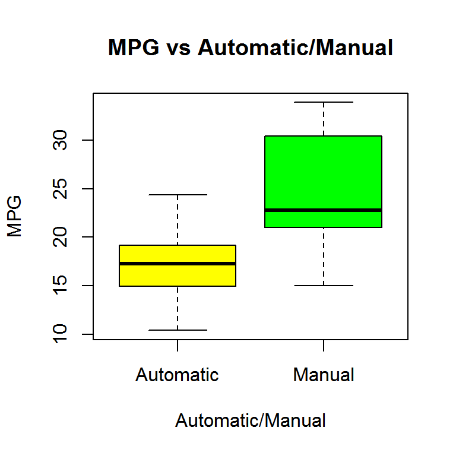

```r
boxplot(mpg ~ am, data = mtcars,
        xlab = "Automatic/Manual", ylab = "MPG",
        main = "MPG vs Automatic/Manual", col = c("yellow", "green"),
        names = c("Automatic", "Manual"))
```

### Pairwise plot

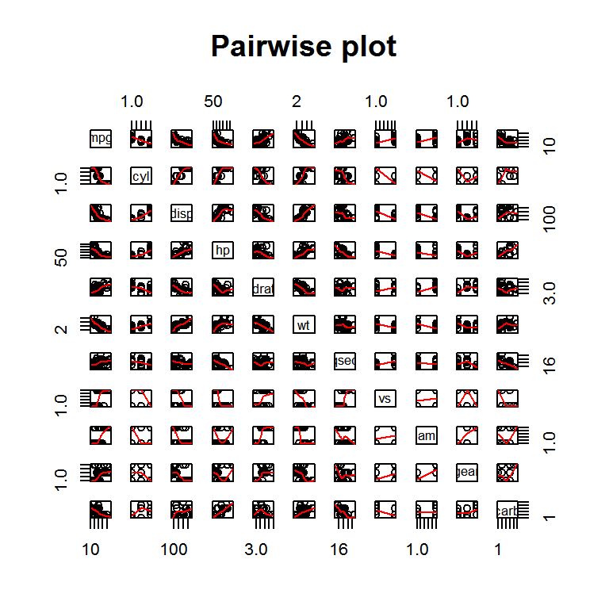

```r
p1ot = pairs(mtcars, panel = panel.smooth, main = "Pairwise plot")
```

### Linear model

```r
fit <- lm(mpg ~ ., data = mtcars)
summary(fit)
```

```
##
## Call:
## lm(formula = mpg ~ ., data = mtcars)
##
## Residuals:
##     Min      1Q  Median      3Q     Max
## -3.5087 -1.3584 -0.0948  0.7745  4.6251
##
## Coefficients:
##             Estimate Std. Error t value Pr(>|t|)
## (Intercept) 23.87913   20.06582   1.190   0.2525
## cyl6        -2.64870    3.04089  -0.871   0.3975
## cyl8        -0.33616    7.15954  -0.047   0.9632
## disp         0.03555    0.03190   1.114   0.2827
## hp          -0.07051    0.03943  -1.788   0.0939 .
## drat         1.18283    2.48348   0.476   0.6407
## wt          -4.52978    2.53875  -1.784   0.0946 .
## qsec         0.36784    0.93540   0.393   0.6997
## vs1          1.93085    2.87126   0.672   0.5115
## amManual     1.21212    3.21355   0.377   0.7113
## gear4        1.11435    3.79952   0.293   0.7733
## gear5        2.52840    3.73636   0.677   0.5089
## carb2       -0.97935    2.31797  -0.423   0.6787
## carb3        2.99964    4.29355   0.699   0.4955
## carb4        1.09142    4.44962   0.245   0.8096
## carb6        4.47757    6.38406   0.701   0.4938
## carb8        7.25041    8.36057   0.867   0.3995
## ---
## Signif. codes:  0 '***' 0.001 '**' 0.01 '*' 0.05 '.' 0.1 ' ' 1
##
## Residual standard error: 2.833 on 15 degrees of freedom
## Multiple R-squared:  0.8931, Adjusted R-squared:  0.779
## F-statistic:  7.83 on 16 and 15 DF,  p-value: 0.000124
```

### Model selection

```r
step_model <- step(lm(mpg ~ ., data = mtcars), trace = 0)
summary(step_model)
```

```
##
## Call:
## lm(formula = mpg ~ cyl + hp + wt + am, data = mtcars)
##
## Residuals:
##     Min      1Q  Median      3Q     Max
## -3.9387 -1.2560 -0.4013  1.1253  5.0513
##
## Coefficients:
##             Estimate Std. Error t value Pr(>|t|)
## (Intercept) 33.70832    2.60489  12.940 7.73e-13 ***
## cyl6        -3.03134    1.40728  -2.154  0.04068 *
## cyl8        -2.16368    2.28425  -0.947  0.35225
## hp          -0.03211    0.01369  -2.345  0.02693 *
## wt          -2.49683    0.88559  -2.819  0.00908 **
## amManual     1.80921    1.39630   1.296  0.20646
## ---
## Signif. codes:  0 '***' 0.001 '**' 0.01 '*' 0.05 '.' 0.1 ' ' 1
##
## Residual standard error: 2.41 on 26 degrees of freedom
## Multiple R-squared:  0.8659, Adjusted R-squared:  0.8401
## F-statistic: 33.57 on 5 and 26 DF,  p-value: 1.506e-10
```

### Compare new model with basic model

```r
initial_model <- lm(mpg ~ am, data = mtcars)
compare <- anova(initial_model, step_model)
compare
```

```
## Analysis of Variance Table
##
## Model 1: mpg ~ am
## Model 2: mpg ~ cyl + hp + wt + am
##   Res.Df    RSS Df Sum of Sq      F    Pr(>F)
## 1     30 720.90
## 2     26 151.03  4    569.87 24.527 1.688e-08 ***
## ---
## Signif. codes:  0 '***' 0.001 '**' 0.01 '*' 0.05 '.' 0.1 ' ' 1
```

### Plot residuals of step model

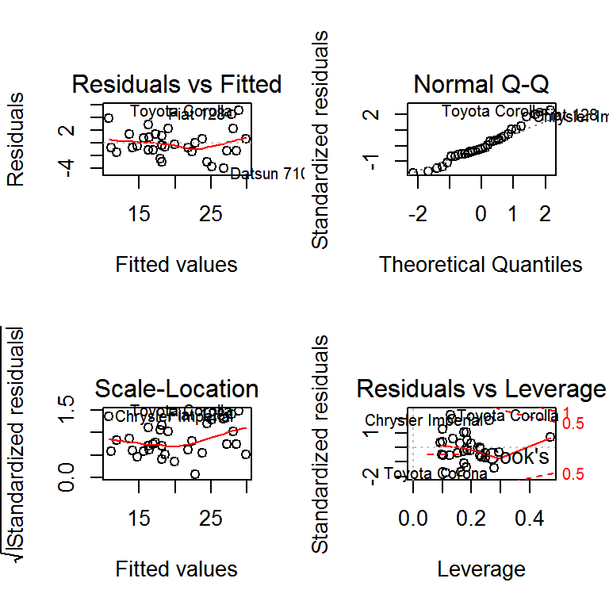

```r
par(mfrow=c(2, 2))
plot(step_model)
```

### t-test

```r
t_test <- t.test(mpg ~ am, data = mtcars)
t_test
```

```
##
##  Welch Two Sample t-test
##
## data:  mpg by am
## t = -3.7671, df = 18.332, p-value = 0.001374
## alternative hypothesis: true difference in means is not equal to 0
## 95 percent confidence interval:
##  -11.280194  -3.209684
## sample estimates:
## mean in group Automatic    mean in group Manual
##                17.14737                24.39231
```